# Ethics and causation

Class

Author

Joshua Loftus

## Discussion 1: absurd trolley problems

In your group, open [Absurd Trolley Problems](https://neal.fun/absurd-trolley-problems/) on one device and play for about six minutes, choosing together. Note the scenarios where the group disagreed, and the ones you personally found hard to choose.

1. Take one scenario where the group disagreed. Which framework was each side using?
2. Did any of your choices depend on a prediction of what would happen? How sure of it were you?

**NoteFrameworks on the track**

In the original problem, pulling the lever to save five people at the cost of one is what a consequentialist who counts lives would do. Refusing to pull it, because diverting the trolley makes you the cause of one death while doing nothing lets five die, is one deontological answer: it rests on a difference between doing and allowing. Other deontologists allow pulling the lever, by the doctrine of double effect: the one death is foreseen but not intended. A virtue ethicist asks what a good person would do there, and can answer either way. Where a choice turned on a prediction, the consequentialist’s answer depended on a causal claim, and the game gives no way to check it.

## Discussion 2: an argument from consequences

On your own, take an argument that justifies a rule or a policy by its consequences: one you brought, or one you think of now, from the news, your university, a job or a company whose service you use. Write it in one sentence, with the cause-and-effect claims it needs and any evidence given for them. Then put your arguments side by side in your group and choose one.

1. What is the action, and which outcome does the argument count? Whose good is counted, and whose is left out?
2. Draw the causal graph the argument needs, with an arrow for each cause-and-effect claim you listed. Mark the action.
3. Try to draw a second graph that fits the same evidence and under which the action does nothing. If the evidence makes every such graph hard to believe, say what in the evidence does that.
4. Argue against the policy without disputing any of its causal claims. Which framework are you using?

Each group’s graph, and its argument from question 4, go on the screen.

**NoteRival graphs**

Most arguments have a rival graph of one of two kinds: a common cause of the action and the outcome, or an arrow that points the other way. A rival graph does not show that your argument is wrong. It shows what evidence would tell the two graphs apart, which is usually a comparison in which the action was not chosen by the people, or the places, that also determine the outcome. If the argument rests on a randomized trial, no common cause of the assignment and the outcome can explain its result, because a coin decided who was assigned the action. What is left to question includes chance, whether what the coin assigned is the action the argument is about (some people do not take what they are assigned), and whether the people in the trial are like the people the policy is for.

**NoteAccepting the causal claims**

A utilitarian who accepts every causal claim can still object that the outcome counted is not the good that matters, or that the count leaves out people the policy affects. A deontologist can object that the policy breaks a rule, such as consent, whatever its effects. A virtue ethicist can object that it expresses a vice, such as indifference to the people it harms. These are disagreements about what matters, and better evidence for the causal claims does not settle them.

## Problems

Before you start, from memory: what does the adjustment formula average, and with what weights?

**NoteSolution**

It averages the outcome among people with $X = x$ within each value of $Z$, with weights $P(Z = z)$: how common each value of $Z$ is in the whole population, not among the people with $X = x$.

### 1. Conditioning and intervening

An insurer’s model of its customers, as a program. $U_1, \dots, U_4$ are independent, with $U_1 \sim \mathrm{Ber}(0.4)$, $U_2 \sim \mathrm{Ber}(0.9)$ and $U_3 \sim \mathrm{Ber}(0.4)$, where $\mathrm{Ber}(0.9)$ is 1 with probability 0.9 and 0 otherwise, and $U_4$ is uniform between 0 and 1.

1. $Z := U_1$ (health-conscious)
2. $X :=$ if $Z = 1$ then $U_2$ else $U_3$ (wears a fitness watch)
3. $Y :=$ 1 if $U_4 < 0.30 - 0.20Z - 0.05X$, else 0 (makes a claim this year)

So $P(Y = 1 \mid Z, X) = 0.30 - 0.20Z - 0.05X$.

1. Draw the graph.
2. Compute $P(X = 1)$, $P(Z = 1 \mid X = 1)$ and $P(Z = 1 \mid X = 0)$.
3. Compute $P(Y = 1 \mid X = 1)$ and $P(Y = 1 \mid X = 0)$. How much less often do customers who wear a watch claim?
4. Suppose every customer wore a watch: $X := 1$. Compute $P(Y = 1 \mid do(X := 1))$ and $P(Y = 1 \mid do(X := 0))$. How much of the difference in (c) is the effect of the watch?
5. The insurer offers customers who wear a watch a discount, citing the difference in (c). Which customers get most of it, and how much of the difference in (c) would the wearers have had without a watch?

**TipHint 1**

For (b), use Bayes’ rule: $P(Z = 1 \mid X = 1) = P(X = 1 \mid Z = 1)\,P(Z = 1)/P(X = 1)$.

**TipHint 2**

For (c), split by $Z$: $P(Y = 1 \mid X = 1) = \sum_z P(Y = 1 \mid Z = z, X = 1)\,P(Z = z \mid X = 1)$.

**TipHint 3**

For (d), replace line 2 by $X := 1$ and keep line 1. What is the distribution of $Z$ now?

**NoteSolution**

1. $Z \to X$, $Z \to Y$ and $X \to Y$.
2. $P(X = 1) = 0.4 \times 0.9 + 0.6 \times 0.4 = 0.6$, $P(Z = 1 \mid X = 1) = 0.4 \times 0.9 / 0.6 = 0.6$ and $P(Z = 1 \mid X = 0) = 0.4 \times 0.1 / 0.4 = 0.1$.
3. $P(Y = 1 \mid X = 1) = 0.6 \times 0.05 + 0.4 \times 0.25 = 0.13$ and $P(Y = 1 \mid X = 0) = 0.1 \times 0.10 + 0.9 \times 0.30 = 0.28$. Customers who wear a watch claim 15 points less often.
4. Setting $X$ leaves line 1 alone, so $Z$ keeps its distribution: $P(Y = 1 \mid do(X := 1)) = 0.4 \times 0.05 + 0.6 \times 0.25 = 0.17$ and $P(Y = 1 \mid do(X := 0)) = 0.4 \times 0.10 + 0.6 \times 0.30 = 0.22$. The watch lowers claims by 5 points. The other 10 points of (c) come from who wears a watch: 60% of the wearers are health-conscious, against 10% of the others.
5. Health-conscious customers, who are 60% of the wearers. Without a watch, the wearers would claim at $0.6 \times 0.10 + 0.4 \times 0.30 = 0.18$, already 10 points below the others’ 0.28. Only 5 of the 15 points are the watch’s effect, which anyone who wears one would get. A discount priced on the 15 points rewards being health-conscious more than wearing a watch.

### 2. Retention offers

A phone company’s model rates each customer high ($Z = 1$) or low ($Z = 0$) risk of leaving. The rating is computed from the customer’s contract, monthly ($T = 1$) or fixed-term ($T = 0$), and from other account data that, we assume, neither affect leaving nor share a cause with it. Customers on monthly contracts are more likely to leave ($Y = 1$: left within three months). The rating is used for one thing only: within each rating, the company chose at random which customers got a retention offer, a discount ($X = 1$), and it offered more of those rated high. The analyst’s data have the rating but not the contract:

| rating | offer | customers | left |
| --- | --- | --- | --- |
| high ($Z = 1$) | yes ($X = 1$) | 150 | 45 |
| high ($Z = 1$) | no ($X = 0$) | 50 | 20 |
| low ($Z = 0$) | yes ($X = 1$) | 100 | 5 |
| low ($Z = 0$) | no ($X = 0$) | 700 | 70 |

1. Draw the graph with $T$, $Z$, $X$ and $Y$.
2. Which of these sets satisfy the backdoor criterion for the effect of $X$ on $Y$: the empty set, $\{T\}$, $\{Z\}$, $\{T, Z\}$?
3. Compute the share who left among customers who got an offer and among those who did not, and the difference.
4. Compute the average treatment effect of the offer with the adjustment formula, and the difference within each rating.
5. Next quarter the company can afford 250 offers, for customers like these. If it wants as few customers as possible to leave, who should get them? Who then never gets an offer, and is that fair?

**TipHint 1**

For (b), a backdoor path starts with an arrow into $X$. What points into $X$, and where does that path lead?

**TipHint 2**

For (d), the adjustment formula weights each rating by its share of all customers, 20% and 80%, not by its share of the customers who got an offer.

**NoteSolution**

1. $T \to Z \to X \to Y$ and $T \to Y$. The rating has no arrow into $Y$: it affects leaving only through the offer, and it predicts leaving because it is computed from the contract.
2. The one backdoor path is $X \leftarrow Z \leftarrow T \to Y$. $\{T\}$, $\{Z\}$ and $\{T, Z\}$ block it, and none contains a descendant of $X$. The empty set leaves it open. $\{Z\}$ works because the offer depended on nothing but the rating and chance: a company that knows how it chose who got an offer can adjust for what it used, as long as each rating includes customers with and without an offer. A rule that offered everyone rated high and nobody rated low would leave nothing to compare within a rating. If the rating also used something else that affects leaving, such as recent complaints, $\{Z\}$ would still work and $\{T\}$ would not.
3. With an offer: $(45 + 5)/250 = 0.20$. Without: $(20 + 70)/750 = 0.12$. Customers who got an offer left 8 points more often.
4. $E[Y \mid do(X := 1)] = 0.30 \times 0.2 + 0.05 \times 0.8 = 0.10$ and $E[Y \mid do(X := 0)] = 0.40 \times 0.2 + 0.10 \times 0.8 = 0.16$, so the average treatment effect is $-0.06$: the offer reduces leaving by 6 points. It reduces leaving by 10 points among customers rated high and by 5 among those rated low. The sign of (c) is reversed because 60% of the offers went to customers rated high, against 7% of the customers without an offer, and customers rated high leave more often with or without one.
5. If the differences within the ratings are the effects, an offer lowers the chance of leaving by 0.10 for a customer rated high and by 0.05 for one rated low. So the offers go to all 200 customers rated high and to 50 rated low: about $200 \times 0.10 + 50 \times 0.05 = 22.5$ fewer customers leave than with no offers, against $150 \times 0.10 + 100 \times 0.05 = 20$ with this quarter’s 250 offers. The 750 customers rated low who get no offer pay full price, and the discounts go to customers who might leave. Whether that is fair is a question about who should bear the cost of keeping customers, which a count of who left cannot answer. The differences are also estimates from one quarter, and the one for customers rated high rests on only 50 customers without an offer.

## Discussion 3: a model that decides about people

Think of a predictive algorithm that makes, or helps to make, decisions with large effects on people: which applicants get a loan, which patients a GP sees first, which benefit claims are checked for fraud. Choose one in your group.

1. Describe the scenario: who uses the model, what it predicts, from what data, and what is decided with it.
2. Half the groups take the four Belmont–Menlo principles, and half take the five Cs (consent; clarity; consistency and trust; control and transparency; consequences). For each one, say what would have to be in place: a feature of the system, or a procedure around it.
3. Which of your requirements could be checked only with a causal claim?

Two or three groups describe their scenario and its requirements to the room.

**NoteAn example: suggestions for GPs**

A model suggests treatments to NHS GPs, to help them get through patient cases faster. It needs private information about each patient, and may store it. It would need, among other things:

- informed consent from the patient, or from someone legally acting for them, to the use and storage of their data, and the data held securely or not at all (respect for persons; consent);
- a clear account to the patient of how the model is used, how their data is used and what happens to the data afterward (clarity; consistency and trust; beneficence);
- no use of the model for a patient who says no (control and transparency; beneficence);
- high accuracy, since a wrong suggestion can harm a patient (beneficence);
- a model that is demonstrably fair across demographic groups, since there are documented cases of medical algorithms biased by race or by sex (justice; consistency and trust);
- storage and processing that meet data-protection law such as the GDPR (respect for law and the public interest);
- care that its records cannot be combined with other sources to identify patients (consequences).

Accuracy is a property of the predictions. Whether patients do better when their GP uses the suggestions than when the GP does not is an effect, and that requirement needs a causal claim.

## Discussion 4: the case for one framework

The room splits into four parts. Each part prepares the strongest case it can for one statement.

1. Ethical data science and AI development requires us to lean mostly on consequentialist ethics.
2. Ethical data science and AI development requires us to lean mostly on deontological ethics.
3. Ethical data science and AI development requires us to lean mostly on virtue ethics.
4. Ethical data science and AI development requires us to lean mostly on pragmatic ethics.

Five minutes to prepare, then a minute for each part. Each case should answer the strongest objection to it. For consequentialism, answer this question: does it become more or less defensible once you have to write the causal model down?

Then everyone votes, whichever part they argued for. Which account are you most convinced of: consequentialist, deontological, virtue or pragmatic ethics, a combination, or none of them?

## If there is time

- “Correlation (more generally, association) is not causation.” This is true and important, but can it be misused?
- Can causality be useful in the context of reproducibility? In designing and communicating studies?
- A company tests two versions of its app on its users, without telling them, to see which version keeps them using the app longer. Which of the Belmont–Menlo principles does this touch? How would each of the four frameworks judge it?
- Find a sentence in a news report of an observational study that avoids saying “causes” but implies a cause. What graph does it assume?

## To finish

One sentence, individually: what is the difference between $P(Y = 1 \mid X = 1)$ and $P(Y = 1 \mid do(X := 1))$?

## For next time

Bring one score or algorithm used to make decisions about people. Write down what it measures and what it stands in for. Every group’s examples will go on the screen.

## Optional, can be done at home

Practice for afterward: problems 3 to 6, then coding A to C. The problems can be done by hand. Attempt each part before you open a hint.

**WarningHints**

Do not open a hint unless you have been stuck for at least a few minutes, and open them in order.

### 3. Omitted-variable bias

In the linear model of the notes, $Z := U_Z$, $X := \alpha Z + U_X$, $Y := \beta X + \gamma Z + U_Y$, with independent mean-zero noise, take $\alpha = 2$, $\gamma = 1$, $\beta = 0.5$ and $\operatorname{Var}(Z) = \operatorname{Var}(U_X) = 1$.

1. Compute $\operatorname{Var}(X)$, $\operatorname{Cov}(X, Z)$ and the slope of $Y$ on $X$ alone.
2. Repeat with $\gamma = -1$.
3. Repeat with $\gamma = 1$ and $\beta = 0$. What would someone with data on $X$ and $Y$ alone conclude?
4. Is the error in (a) a bias or a variance? What happens to it as the sample grows?

**TipHint 1**

$Z$ and $U_X$ are independent, so $\operatorname{Var}(X) = \alpha^2 \operatorname{Var}(Z) + \operatorname{Var}(U_X)$.

**NoteSolution**

1. $\operatorname{Var}(X) = 4 + 1 = 5$ and $\operatorname{Cov}(X, Z) = \alpha \operatorname{Var}(Z) = 2$. The slope is $\beta + \gamma \operatorname{Cov}(X, Z)/\operatorname{Var}(X) = 0.5 + 2/5 = 0.9$.
2. $0.5 - 2/5 = 0.1$: the bias has the sign of $\gamma\alpha$, and here it almost hides the effect.
3. $0 + 2/5 = 0.4$. They would see a positive slope and could conclude that raising $X$ raises $Y$, when intervening on $X$ does nothing.
4. A bias. The slope converges to $0.9$ as the sample grows: the estimates concentrate around $0.9$, not around the effect, $0.5$.

### 4. Choosing an adjustment set

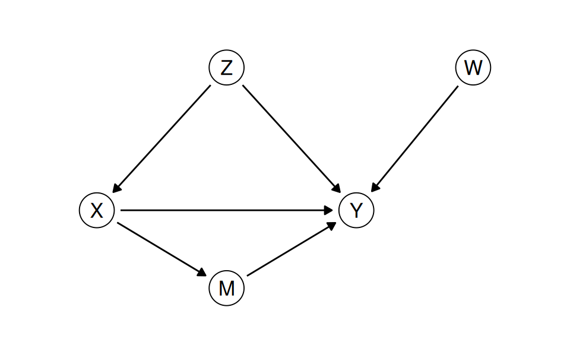

1. List the backdoor paths from $X$ to $Y$.
2. Which of these sets satisfy the backdoor criterion: the empty set, $\{Z\}$, $\{M\}$, $\{Z, M\}$, $\{W\}$, $\{Z, W\}$?
3. In a linear model, what does the coefficient on $X$ estimate if you adjust for $\{Z, M\}$?
4. If more than one of the sets in (b) satisfies the criterion, which would you use, and why?

**TipHint 1**

A backdoor path starts with an arrow into $X$. How many arrows point into $X$?

**NoteSolution**

1. One: $X \leftarrow Z \to Y$.
2. $\{Z\}$ and $\{Z, W\}$. The empty set and $\{W\}$ leave the back door open. $\{M\}$ and $\{Z, M\}$ contain a descendant of $X$.
3. The direct effect of $X$, along the arrow $X \to Y$: the part that does not go through $M$. It is not the total effect of $X$. (It is the direct effect because in this graph nothing else affects both $M$ and $Y$.)
4. $\{Z\}$ and $\{Z, W\}$ both satisfy it. Use $\{Z, W\}$: $W$ is not a confounder, so leaving it out causes no bias, but it explains some of the variation in $Y$, and the estimate that uses it is usually less variable.

### 5. The graph behind an argument

A university says: “Students who use the library more get better grades. We will extend the library’s opening hours, because using the library improves grades.”

1. Draw the causal graph the argument presupposes, and mark the action.
2. Add one variable that would make the observed difference larger than the effect, with its arrows.
3. What comparison would support the university’s claim?

**TipHint 1**

The university’s evidence compares students. Its action changes opening hours. Are those the same thing?

**NoteSolution**

1. Opening hours (the action) $\to$ library use $\to$ grades. The argument needs the arrow from library use to grades, and an arrow from opening hours to library use.
2. For example motivation, or how well a student was already doing, with arrows into library use and into grades. If it raises both, the students who use the library more would have had better grades anyway, so the observed difference is larger than the effect.
3. Grades before and after the hours were extended, against a comparable university or set of courses where they were not; or terms, or sites, chosen at random to have longer hours. The comparison of students who use the library more with those who use it less answers a question about those students.

### 6. Hormone therapy

The notes’ section on hormone therapy and heart disease gives three studies of whether to prescribe hormone therapy to prevent heart disease.

1. Write the decision with $X$ and $Y$. Say what the treatment and the outcome are, and write the quantity a doctor needs with $do(\cdot)$.
2. The 1996 estimate (0.39) and the 2008 estimates (1.42 over the first two years, 0.96 over the whole follow-up) come from the same cohort. Which comparison did each make?
3. Draw a graph under which the 1996 estimate is confounded.
4. Which comparison matches the decision a doctor makes, and why?

**TipHint 1**

For (a), what does the doctor choose, and which outcome is the choice about? For (b), ask which two groups each analysis compares.

**NoteSolution**

1. $X = 1$ if the doctor prescribes hormone therapy, $Y = 1$ if the woman has coronary heart disease within five years. A doctor needs $P(Y = 1 \mid do(X := 1))$ against $P(Y = 1 \mid do(X := 0))$, not $P(Y = 1 \mid X = 1)$ against $P(Y = 1 \mid X = 0)$.
2. 1996: women who took estrogen with progestin against women who did not use hormones, adjusted for measured confounders. 2008: women who started against women who did not start, both followed from the same point, analyzed as the trial was.
3. Socioeconomic status $\to$ hormone use, socioeconomic status $\to$ heart disease, with or without an arrow from hormone use to heart disease.
4. The 2008 comparison. The doctor’s decision is whether to start, and that comparison follows women from the point at which they started or did not.

### Coding

Open a fresh R script. You will need the tidyverse.

#### A. Prediction and intervention

```r
n <- 10000
# program 1: X causes Y
X1 <- rnorm(n); Y1 <- 2 * X1 + rnorm(n)
# program 2: Z causes both
Z2 <- rnorm(n); X2 <- Z2 + rnorm(n); Y2 <- Z2 + rnorm(n)
# program 3: X causes Y through M
X3 <- sqrt(2) * rnorm(n); M3 <- X3 + sqrt(2) * rnorm(n); Y3 <- 0.5 * M3 + rnorm(n)
```

1. Write down the slope of $Y$ on $X$ you expect in each program. Then fit `lm` and compare.
2. For each program, intervene: set $X$ to 1 for everyone and run the statements after the one for $X$ again, then the same with $X$ set to 0. Compute the difference in the means of $Y$.
3. In program 2, fit `lm(Y2 ~ X2 + Z2)`. In program 3, fit `lm(Y3 ~ X3 + M3)`. Compare the coefficients on $X$ with your answers to 2.

**TipHint 1**

In each program, which statements after the one for $X$ use $X$, directly or through a variable computed from it? Those are the ones whose values change when you set $X$.

**NoteSolution**

```r
slopes <- c(coef(lm(Y1 ~ X1))[2], coef(lm(Y2 ~ X2))[2], coef(lm(Y3 ~ X3))[2])
do1 <- c(mean(2 * 1 + rnorm(n)),                    # X set to 1, later statements re-run
         mean(Z2 + rnorm(n)),
         mean(0.5 * (1 + sqrt(2) * rnorm(n)) + rnorm(n)))
do0 <- c(mean(2 * 0 + rnorm(n)),                    # X set to 0
         mean(Z2 + rnorm(n)),
         mean(0.5 * (0 + sqrt(2) * rnorm(n)) + rnorm(n)))
round(rbind(slope = slopes, effect = do1 - do0), 2)
```

```
         X1    X2   X3
slope  1.99  0.51 0.50
effect 1.99 -0.01 0.54
```

```r
round(coef(lm(Y2 ~ X2 + Z2))[2], 2)    # program 2, adjusting for Z
```

```
X2
 0
```

```r
round(coef(lm(Y3 ~ X3 + M3))[2], 2)    # program 3, adjusting for M
```

```
  X3
0.01
```

The slopes are about 2, 0.5 and 0.5. The effects are about 2, 0 and 0.5. In programs 2 and 3, $X$ and $Y$ have the same joint distribution (jointly normal, with means 0, variances 2 and 2 and covariance 1), so $X$ predicts $Y$ equally well in both, and intervening on $X$ changes $Y$ only in program 3. Adjusting for $Z$ in program 2 gives a coefficient near 0, the effect. Adjusting for $M$ in program 3 also gives a coefficient near 0. That is the direct effect, zero here because $X$ reaches $Y$ only through the mediator $M$; the total effect is 0.5.

#### B. Adjustment on data

The table of problem 2, one row for each customer.

```r
cells <- data.frame(Z = c(1, 1, 0, 0), X = c(1, 0, 1, 0),
                    n = c(150, 50, 100, 700), left = c(45, 20, 5, 70))
customers <- bind_rows(
  cells |> mutate(Y = 1, count = left),
  cells |> mutate(Y = 0, count = n - left)
) |>
  select(Z, X, Y, count) |>
  tidyr::uncount(count)
nrow(customers)
```

```
[1] 1000
```

1. Compute the share who left among customers with an offer and without one, from `customers`, and the difference.
2. Compute the adjusted difference: the difference within each value of $Z$, averaged with weights $P(Z = z)$.
3. A randomized version: send each of the 1,000 customers the offer with probability 0.25, whatever their rating, and draw whether they leave from the table’s rates. Compute the difference. Repeat 200 times. What is the average difference, and how much does it vary?

**TipHint 1**

For 2: `customers |> group_by(Z) |> summarize(...)` gives one row for each value of $Z$; compute the difference and the share of customers in each row there.

**NoteSolution**

```r
customers |> group_by(X) |> summarize(rate = mean(Y))
```

```
# A tibble: 2 x 2
      X  rate
  <dbl> <dbl>
1     0  0.12
2     1  0.2
```

```r
rows <- customers |>
  group_by(Z) |>
  summarize(diff = mean(Y[X == 1]) - mean(Y[X == 0]),
            share = n() / nrow(customers))
sum(rows$diff * rows$share)
```

```
[1] -0.06
```

```r
rate <- function(z, x) {
  ifelse(z == 1, ifelse(x == 1, 0.30, 0.40), ifelse(x == 1, 0.05, 0.10))
}
one_trial <- function() {
  Z <- rep(c(1, 0), times = c(200, 800))
  X <- rbinom(1000, 1, 0.25)
  Y <- rbinom(1000, 1, rate(Z, X))
  mean(Y[X == 1]) - mean(Y[X == 0])
}
trials <- replicate(200, one_trial())
c(mean = mean(trials), sd = sd(trials))
```

```
       mean          sd
-0.06203411  0.02336745
```

1. 0.20 and 0.12, a difference of 0.08.
2. $-0.06$.
3. The average is close to $-0.06$, and the differences vary from trial to trial with a standard deviation of about 0.02. Randomization removes the bias without any model of $Z$ or $T$, and the price is that a single trial can miss by a few points.

#### C. Intervening in a program

The job center from the lecture, as a program. As in the lecture, everyone referred attends and nobody else does. Each line generates one variable from the ones above it.

```r
n <- 10000
Z <- rbinom(n, 1, 0.5)                        # worked last year
X <- rbinom(n, 1, ifelse(Z == 1, 0.8, 0.2))   # attended the course
Y <- rbinom(n, 1, 0.3 + 0.1 * X + 0.3 * Z)    # in work six months later
mean(Y[X == 1]) - mean(Y[X == 0])             # attenders against the others
```

1. Run it. Compare the difference with the lecture’s first job-center table (64% against 36%).
2. Compute the adjusted difference: the difference between attenders and non-attenders within $Z = 1$ and within $Z = 0$, averaged with weights `mean(Z == 1)` and `mean(Z == 0)`.
3. Intervene. Replace the line for `X` by `X <- rep(1, n)`, run the line for `Y` again, and record `mean(Y)`. Do the same with `X <- rep(0, n)`. Compare the difference with your answer to 2.
4. The center changes its referrals to 0.95 for $Z = 1$ and 0.05 for $Z = 0$. Before you run anything, write down what you expect for the differences in 1 and in 3. Then run it.

**TipHint 1**

For step 3, replace the line for `X` and leave the line for `Z` alone. Then run the line for `Y` again, so that it uses the new `X`.

**NoteSolution**

```r
set.seed(313)    # the sheet's seed, so this output does not depend on the chunks above it
n <- 10000
Z <- rbinom(n, 1, 0.5)
X <- rbinom(n, 1, ifelse(Z == 1, 0.8, 0.2))
Y <- rbinom(n, 1, 0.3 + 0.1 * X + 0.3 * Z)
observed <- mean(Y[X == 1]) - mean(Y[X == 0])
d1 <- mean(Y[X == 1 & Z == 1]) - mean(Y[X == 0 & Z == 1])   # within Z = 1
d0 <- mean(Y[X == 1 & Z == 0]) - mean(Y[X == 0 & Z == 0])   # within Z = 0
adjusted <- d1 * mean(Z == 1) + d0 * mean(Z == 0)
Y1 <- rbinom(n, 1, 0.3 + 0.1 * 1 + 0.3 * Z)    # everyone attends
Y0 <- rbinom(n, 1, 0.3 + 0.1 * 0 + 0.3 * Z)    # nobody attends
c(observed = observed, adjusted = adjusted, intervened = mean(Y1) - mean(Y0))
```

```
  observed   adjusted intervened
 0.2813623  0.1046528  0.1067000
```

```r
X95 <- rbinom(n, 1, ifelse(Z == 1, 0.95, 0.05))
Y95 <- rbinom(n, 1, 0.3 + 0.1 * X95 + 0.3 * Z)
mean(Y95[X95 == 1]) - mean(Y95[X95 == 0])      # observed, new referrals
```

```
[1] 0.3798091
```

1. About $0.28$, the table’s $0.64 - 0.36$.
2. About $0.10$.
3. About $0.10$: intervening deletes the arrow $Z \to X$, and the adjusted difference estimates the same quantity.
4. The observed difference grows to about $(0.95 \times 0.7 + 0.05 \times 0.4) - (0.05 \times 0.6 + 0.95 \times 0.3) = 0.685 - 0.315 = 0.37$. The effect of the course stays at $0.10$: the referral policy changes who attends, not what the course does. Each run differs from these numbers by a few hundredths.